# Models for Market Sales Variation Simulation

Kin

August 15, 2016

# 1 Abstract

In this report, different models will be attempted to describe and simulate the market sales of the mainstream tea products provided by Kantar. The whole simulation consists of two parts. The first part of the model is to model the tea consumption rate of the households with reference to the latent class method adopted by Kamakura and Russel(1989). Given the occasions of buying tea, a latent class analysis was adopted to find out the underlying tea consumption rate of each household in terms of the number of tea products purchased per year. The goal of this part is to explain the change in yearly tea consumption of households by a random distribution and estimate their underlying consumption rate. In the second part of the model, the brand choice of each household was investigated by different kinds of multi-logit model using the gmnl package in R-CRAN created by Mauricio Sarrias and Ricardo A.Dziano(2015) and the model described by Fiebig et al. (2010). In the past decades, many different kinds of branches of multi-logit models were developed and tested, aiming to solve the two main problems of the vanilla model, namely the heterogeneity problem of individuals and the constant competition among alternatives (known as the IIA property). In this part, different kind of multi-logit model will be discussed with reference to some recent researches. After that, different models were attempted for fitting, aiming to find the best choice model to describe the data.

# 2 Data

This report used the tea panel data provided Kantar in year 2014-2015, constrained to the “Mainstream” sub-sector category.

The data is composed of 5 different databases:

1.) Demographical data of households - 14074 Houses

2.) Attributes of tea products - 4530 products

3.) Attributes of Stores/shops - 826 stores

4.) Sales of tea products - 14074 observations

5.) Trips to stores/shops - 835530 observations

In the first part of the model, 80% of the households with their full shopping record were used to model their tea consumption pattern. In the second part of the model, due to the complexity and computation cost, only 5000 households were sampled to test the application of different models. For the brands, top 5 major brands i.e. P.G. Tips, R.Twining, Tetley Standard Bags, Typhoo and Yorkshire Tea were chosen and specified while the rest of the brands were aggregated into other brands(others_BRD) and other private labels(others_PL).

# 3 Modelling tea product sales

To understand the variation of market sales, it is important to understand the variation of tea using habit. From the internship research, it was observed that there was a certain degree of tea consumption change from year to year. However, as the total sales of tea tends to remain the same every year, it was believed that the underlying expected tea consumption for each household remain the same every year. Enlightened by the latent class multinomial logit model, the following model was built to find out the consumption rate structure of the market as well as the estimated individual tea consumption rate.

Assumed the probability of tea purchases could be modeled by a Poisson process and all the households has a fixed latent probability of buying a tea product. From the observed number of tea purchase each year, the underlying parameters of such distribution can then be estimated. Using the Poisson distribution and the shopping history in 2014 and 2015, the percentage of the sample population with different tea consumption rate was estimated by a maximum likelihood optimization.

Let the possible yearly tea consumption rate be $k=0.05, 0.1,0.2,0.3,...,1,2,3,...,140$ and $POIS(a,\lambda)$ be the Poisson probability distribution with $a$ the observed value and $\lambda$ the expected value. For each household, the likelihood of $\lambda$ was calculated with the amount of tea product purchased in different period using Bayes Theorem,

$$\text{posterior}=\frac{\text{prior} \times \text{likelihood}}{\text{evidence}}$$
.

Let $C_k$ be the case that a household has a latent tea consumption rate of $\lambda=k$ purchase per year and $x$ its purchase history, then by Bayes Theorem, the probability of it belonging to $C_k$ given a tea purchasing history $x$ can be estimated as,

$$p(C_k \vert \mathbf{x}) = \frac{p(C_k) \ p(\mathbf{x} \vert C_k)}{p(\mathbf{x})}$$
,

where the probability $p(C_k)$ was estimated by maximizing the overall likelihood of obtaining the observed tea sales history.

Assume that $\Sigma_k p(\mathbf{x} \vert C_k) = p(x)$ and together with the fitted $p(C_k)$, the probability of the latent tea purchase number of each households $p(C_k|x)$ can be estimated according to $p(C_k)$ by $p(C_k \vert \mathbf{x}) = \frac{p(C_k) \ p(\mathbf{x} \vert C_k)}{p(\mathbf{x})}$ and further applied for market sales variation simulation.

There is still a problem regarding the recorded history of purchase. As the history was made up by observed purchase, those seldom tea buyers who made no purchase in the recorded years were neglected and therefore causing an error to the model. To find out those “hidden” potential buyers, notice that the probability $P(C_k)$ estimated was a conditional probability of the class memberships given that the household was observed. i.e. Only if the household had made at least 1 purchase in either year. From the sample population of $N$ households, the number of households $N_{k}$ in each class with consumption rate $k$ could be estimated by finding out the expected population in the class given the amount of observed population in the sample,

$$N_{k}=\frac{N \times P(C_k)}{1-POIS(0,k)^2}$$
.

The number of hidden households $N_{0k}$ can then be evaluated according to,

$$N_{k0}=N \times P(C_k) - N_{k}$$

The likelihood of the class distribution is -25476.7350 with a total of 811 hidden households from all different classes. The memberships of these hidden households is printed in the Table 1.0 below.

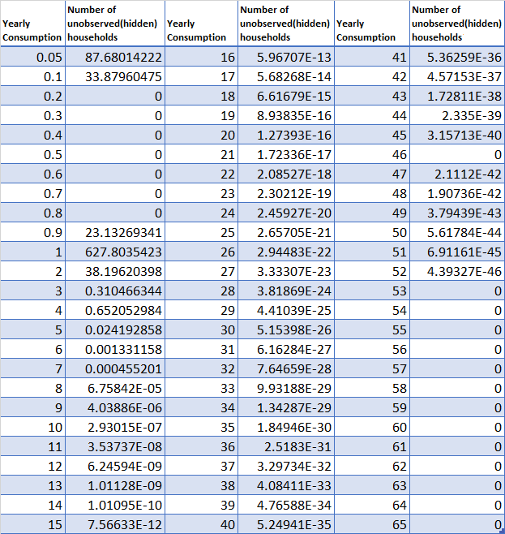

Table 1.0 The class distribution of tea consumption

The result of the class memberships of recorded households is plotted below in Fig 1.1. and the estimated tea consumption population is printed in Table 1.1.

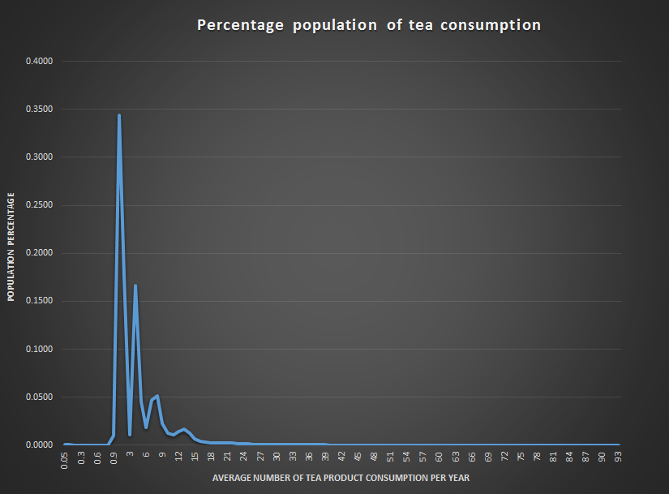

Fig 1.1 The class distribution of tea consumption

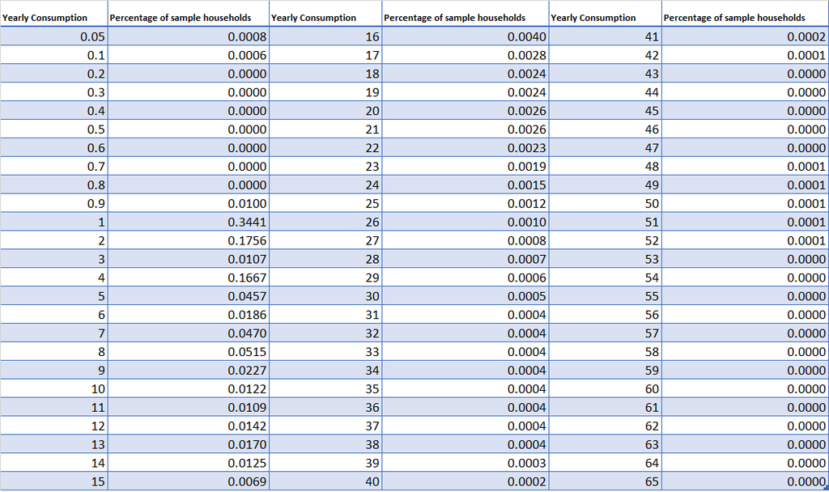

Table 1.1 Tea consumption rate in the sample population

To briefly check the result by Monte Carlo simulation, the change in tea consumption pattern of the recorded result was compared with that of the simulated result.

The y-axis shows the number of tea purchased in the year 2014 while the x-axis shows the number of tea consumed(purchased) in the year 2015. The entries of the tables were the number of households.

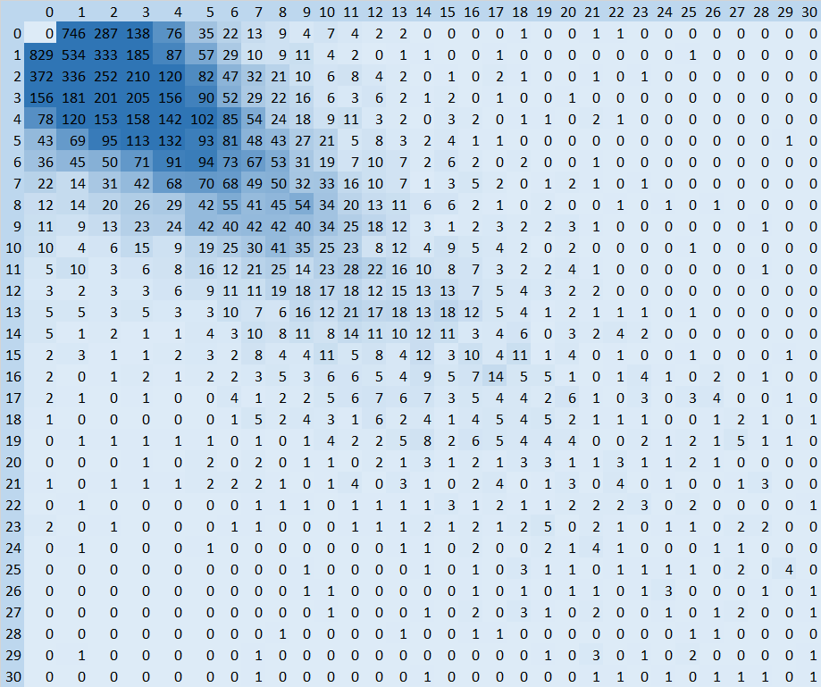

Table 1.2 The recorded change of the number of tea purchased

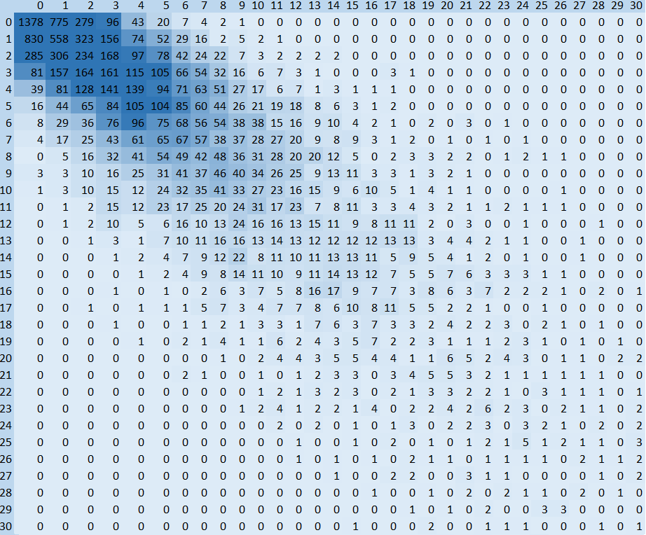

Table 1.3 The simulated change of the number of tea purchased

The simulated result shares a very similar shape with the recorded history. However, for the frequent buyers of tea, there are less extreme changes of consumption rate in the record than in the simulated result, meaning that a Poisson distribution may not be a very accurate estimation for frequent buyers of tea. There seems to be a trend of increasing stability of consumption rate as the mean of consumption rate increases. We can see from the plots that the distribution of the real record seems to be more concentrated at the diagonal than the simulated record as the mean consumption rate increases. After observing such behavior, the next step of this model could be re-scaling the distribution function to describe the trend of increasing stability. The plots below indicate the difference described above.

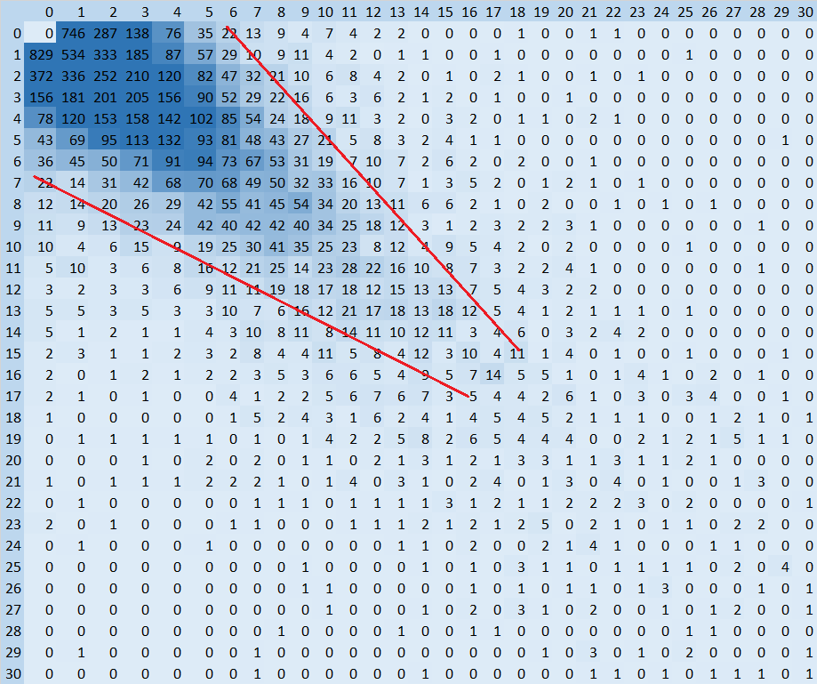

Table 1.4 The red lines indicated the amount changes in recorded consumption as consumption rate increases.

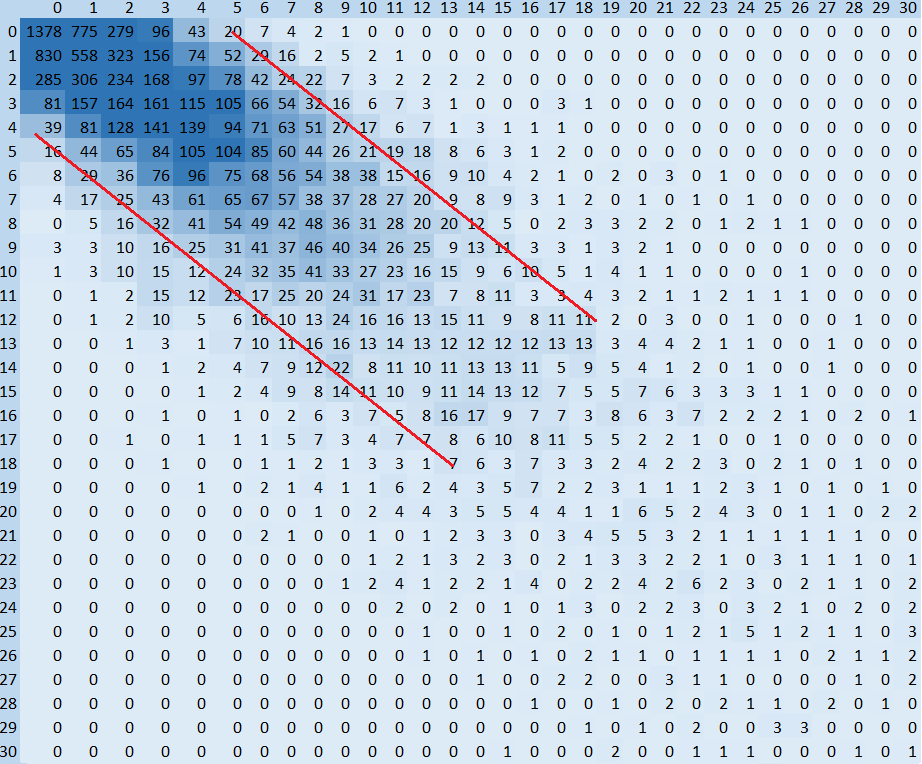

Table 1.5 The red lines indicated the amount changes in simulated consumption as consumption rate increases.

# 4 Modelling brands choice

In the past decades, many different types of multinomial logit model were developed and tested on different fields to model discrete choices. In this part of our model, a different variation of multinomial logit model will be tested and applied, aiming to find out the best multi-logit model to describe the brand choices.

## 4.1 Data treatment

As the each brand has different branches of products with different price and promotion, works must be done to simplify the model. Each product was weighted according to their percentage sales within the brand. For example, if brand x consists of products A, B, and C, then the weight of A was calculated as,

$$\frac{\text{sales of A}}{\text{sales of A}+\text{sales of B}+\text{sales of C}}$$
.

Such weighting was then applied to the alternative specific variables. Furthermore, as the models require quite complicated algorithms, most of them require from 7 to 20+ hours to run one single simple model. So in a trial set of 5000 households was sampled from the data for testing of different models.

## 4.2 Choice Models

Multinomial logit model is a very popular choice model in different field. The model consists of individuals and alternatives. Individuals$(n)$ are those who makes the decision of choice. In case of retail marketing, they are usually households or shoppers. Alternatives$(j)$ are those choices that can be made by individuals, in case of retail marketing, they are usually different brands or products. The decision of choice of individuals are then modeled to be made according to the utility of alternatives,

$$U_{njt}=\beta x_{njt} + \epsilon_{njt}$$
,

where,

$\epsilon_{nt}$: extreme distributed idiosyncratic error term;

$U_{jt}$: the utility level of choice $j$ at time $t$;

$x_{jt}$: the alternative specific attributes of alternative $j$ observed by the individual at time $t$;

$\beta$: the vector of weights.

The probability of making a choice of alternative $j$ is then calculated as,

$$P(j| X_t)=\frac{exp(\beta x_{jt})}{\Sigma_{k=1}^J exp(\beta x_{kt})}$$

where $X_t$ the observed attributes of all alternatives by the individual at time $t$.

This model is often know to have the following two problems as well exist in our case.

1. Heterogeneity of Individuals

Parameters $\beta$ within the model are shared by all the individuals which imply implicitly that all the individuals react the same to all attributes which are generally tested or believed to be wrong.

2. Constant Competition of Alternatives(IIA property)

Consider the competition between alternative $i$ and $j$ as the ratio of probability of choosing $j$ and $i$,

$$P(j| X_t)/P(i| X_t)=exp(\beta x_{jt} - exp(\beta x_{jt}))$$
.

The formula indicates that the competition is always independent of the existence of other alternatives. However, it is trivial that the existences of other alternatives do affect the competition between brands. For example, if an alternative $k$ looks exactly the same as $i$ appeared,
$$P(j| X_t)/P(i| X_t)$$
is very likely to increase. However, the model failed to capture such effect.

As a result of the problems above, three main branches of multinomial logit models were developed.

## 4.3 Latent Class Model(LC)

This model is developed mainly to deal with the problem of heterogeneity of individuals. Instead of using a fixed constant, individuals were assigned a probability of different class membership and each class is assigned to different parameters. As a result, individuals with different reactions to alternatives attributes will be assigned to a different class with different probability and therefore the heterogeneity can be expressed. As the number of class allowed increases, more of the heterogeneity of individuals is allowed to be expressed. The hidden attributes of individuals and their effects on choices are expressed by the probability of class memberships, the respective ASCs and the coefficients of different alternative attributes.

Under this model, the utility of each individual $n$ in class $c$ is then evaluated as,

$$U_{cjt}=\beta_c x_{njt}$$
.

and therefore,

$$P(h_n | c)= \frac{exp(\beta_c x_{njt})}{\Sigma_{k=1}^J exp(\beta_c x_{nkt})}$$

Let there be classes $c=1,...,C$.

The probability of an individual $n$ belonging to class $c$ having a purchase history $h_n$ is,

$$P(c|h_n)=\frac{P(h_n|c)P(c)}{P(h_n)}$$
.

Assume that every individual must at least belong to a class, then,

$$P(h_n)=\frac{P(c)P(h_n|c)}{\Sigma_{c^{'}}^C P(c^{'})}$$
.

Combining the equations above, we have $P(h_n)$ in terms of $P(c^{'})$ and $beta_c^{'}$ for $c^{'}=1,...,C$. Thus the overall likelihood of obtaining the observed purchase history of the whole sample is $\Pi_n P(h_n)$. By finding the maximum likelihood, optimal $P(c^{'})$ and $beta_c^{'}$ are obtained for $c^{'}=1,...,C$.

Let $\omega_{nc}=P(c|h_n)$, then the probability of individual $n$ making a sequence of choice $h_n$ over the time period $t=1,...,T_n$ can be written as,

$$P_n(h_n)= \Sigma_{c=1}^C [ \Pi_t^T \Pi_j^J \{\frac{exp(x_{njt}^T \beta_c)}{\Sigma_{j=1}^J exp(x_{njt}^T \beta_c)}\}^{y_{njt}} ]$$

where $y_{njt}$ is a dummy variable indicating the decision of purchase of choice $j$ at time $t$ by individual $n$ and $h_n$ can be considered as an array of $j$ and $t$ with entries $y_{njt}$.

### 4.3.1 Model application and results

To apply the latent class model, a different number of classes was tested to find out the best model. To keep the model simple, only weighted promotion and alternative specific constants(ASC) were used in the model. The promotion variables were simplified to a single dummy variable indicating whether there is a promotion or not. So for each product in each brand, the dummy variable was assigned to be 1 for there was a promotion(any type of promotion) or 0 if there was no promotion. The dummy variable was then further weighted according to their percentage product sales within the brand. The overall brand promotion index was calculated by summing up all the weighted promotion variables of each product. The ASCs were expected to explain the underlying preference differences between individuals caused by unknown factors while the promotion index worked as a controlled factor.

The LC model was tested with a different number of classes with the trial dataset of 5000 households, the results of the tested models were presented below.

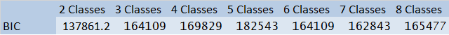

Table 2.1 The BIC of the LC models with different number of classes

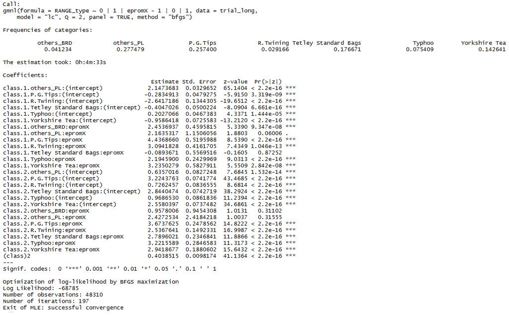

Table 2.2 The best-fitted LC model with the trial data

From the above, the best-fitted model for the trial dataset was found to be with 2 classes. Class one contains mainly households who usually buy the private label products. The coefficients of the promotion indexes of different brands are all significant and positive except for the Tetley Standard Bags and private label. The reason behind could be because of lacking data purchase record from households from this class. Another possible reason of obtaining insignificant coefficient for the private label brands could be because those private labels were usually very cheap and considered to be under promotion already and therefore there was rarely marked promotion for those products.

### 4.3.2 Discussion - LC

Theoretically, the more classes allowed for the model, more the heterogeneity can be expressed by the model. However, the computing cost and complexity of the model increases quickly proportional to the number of classes allowed. Consider a vanilla model with 4 to 5 explanatory variables, which is quite usual in many cases, and it is decided to have n classes. The number of parameters in the LC model will be 4n to 5n. If n is 5, then there will be over 20 parameters to be estimated. It is therefore often argued that the ability of this model to explain heterogeneity is very limited as the cost increases too quickly as the number of classes increases. Furthermore, the problem of constant competition among alternatives still remains unsolved.

However, the LC model does not require any prior information about the shape or distribution of any individual variables of the data, making it generally easier to apply than other models such as Mixed Multinomial Logit(MIXL) or Scaled Multinomial Logit(SMNL). Furthermore, the latent class clustering within the model allows practitioners to discover different types of individuals, making it easier to understand and more interesting. The preference of individuals could be explained by the ASCs of their class memberships and therefore require less knowledge of the attributes of alternatives.

The next step of the LC model could be increasing the number of class allowed to find the optimal number of classes in terms of the best BIC value or introducing demographical variables to explain the class membership. Being able to describe the class membership distribution by demographical factors could be very useful as that will enable the prediction of market sales based on demographical composition. Furthermore, it would be very useful if the attributes of different tea could be introduced into the model to explain the choice of shoppers and it would be very interesting to investigate the relationship between the choice of brands within a shopper’s basket.

Furthermore, it would be useful to include different alternative characteristics into the model to explain the competition between brands as there is hardly a way to compare the price of different products fairly without considering other individual preference of alternatives attributes such as quality and package size preference. By applying the same weighting method as on promotion, indexes of different attributes can be evaluated from the portfolio of products of each brand.

Given a set of demographical characteristics $D_n$ of individuals $n$, the class membership could be modelled with individual demographical factors as,

$$\omega_{nc}=\frac{exp(D_n^T \gamma_c)}{\Sigma_{c^{'}=1}^C exp(D_n^T \gamma_c)}$$
,

where $\gamma_c$ is the class specific coefficients for the individual specific demographical variables[1].

## 4.4 Mixed Multinomial Logit Model(MIXL/MMNL)

To take care of both individual heterogeneity problem and the constant competition(IIA) problem, some researchers (e.g. McFadden and Train 2000) suggested the Mixed Multinomial Logit Model. Instead of applying fixed parameters, M-MNL models the parameters as random variables with pre-defined distributions. The main focus of this model is to model the difference in the importance of different alternative attributes to different individuals.

The utility levels of the alternatives are evaluated arithmetically with an extreme distributed idiosyncratic error. Hence, the heterogeneity can be described by the pre-defined distribution and its fitted parameters. Furthermore, it also fixes the constant competition problem.

The utility level of individual $n$ in the model is now evaluated as,

$$U_{njt}=\beta_n x_{njt}^T + \epsilon_{njt}$$
,

where $\beta_n=\beta + L \eta_n$.

$\beta$ is a vector of the mean of parameters among individuals and $\eta_n$ is randomly distributed according to some pre-defined distribution parameterized by mean 0 and fitted standard deviation $\Sigma$. $L$ is the Cholesky factor of $\Sigma=VAR(\beta_n)=LL^T$.

While the LC model can be considered as describing such heterogeneity by a discrete distribution of classes, the MIXL model can be considered as describing the heterogeneity with a pre-defined continuous distribution. Consider $f(\beta_n)$ a distribution function of $\beta$, the probability of an individual making a sequence of choice $h_n$ over the time period $t=1,...,T_n$ can be written as,

$$P_n(h_n)= \int [ \Pi_t^T \Pi_j^J \{\frac{exp(x_{njt}^T \beta_i)}{\Sigma_{j=1}^J exp(x_{njt}^T \beta_i)}\}^{y_{njt}} ] f(\beta_i)d\beta_i$$
.

### 4.4.1 Model application and results

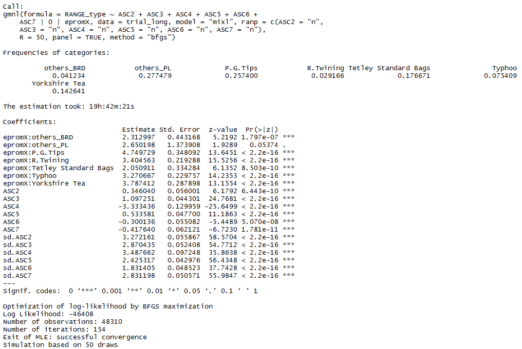

Table 3.2 The MIXL model with the trial data

The ASC above stands for alternative specific variables and their respective brands are printed below.

ASC1:others_BRD

ASC2:others_PL

ASC3:P.G.Tips

ASC4:R.Twining

ASC5:Tetley Standard Bags

ASC6:Typhoo

ASC7:Yorkshire Tea

### 4.4.2 Discussion - MIXL/MMNL

The main difficulty to apply the MMNL is to specify the underlying distribution of parameters. Often, the marketing data provided will not be big enough to provide individual level data to explicitly work out the distribution. As a result, it is often defined by the practitioner according to their intuition or experience. It is often assumed to be normally distributed but it is not necessarily true.

Although this model is relatively cheap in terms of its computational cost, it still requires a long time(up to 20 hours) to run a simple model on the trial dataset. As a result, very limited number of models can be tested. The next step could be further introduction of different variables or testing different distributions of parameters. $\beta_n$ can be further modeled as,

$$\beta_n= \beta + \Pi D_n + \eta_n$$

To further explain heterogeneity, some researchers proposed the nested MMNL model within LC, called Mixture of Mixed Multinomial Logit Model(MM-MNL). Recently, many types of research have been done on investigating the explanatory power between MIXL and the Scaled Multinomial Logit Model(SMNL) and found that the SMNL generally performed better.

The next step for the model could be including more attributes variables of alternatives, namely Caffeine Level, Fairtrade and Organic. Variables such as the variety of product presented in the shop could also be introduced to the model.

Despite the popularity of MIXL, many recent researches found that the heterogeneity of parameters was better described by scaling of parameters.

## 4.5 Scaled Multinomial Logit Model(SMNL)

Instead of explaining the heterogeneity by assuming there is an underlying distribution of parameters among individuals like MMNL, it is suggested that such variation is better described by a randomly distributed scale factor of the parameter $\sigma_n$,

$$U_{njt}=\sigma_n \beta x_{njt}^T + \epsilon_{njt}$$
,

$$\sigma_n=exp(\bar{\sigma}+\tau \nu_n)$$
,

where $\nu$ is randomly distributed and $\bar{\sigma}$ is the mean of $\sigma_n$ simulated by,

$$\bar{\sigma} = -log[\frac{1}{N} \Sigma_{n=1}^N exp(\tau \nu_n)]$$
,

where $N$ is the number of samples for simulation.

So it can be considered as modelling the difference in importance of attributes to different individuals.

Alternatively, the same model can be expressed as,

$$U_{njt}= \beta x_{njt}^T + \frac{\epsilon_{njt}}{\sigma_n}$$
,

and, therefore, the random idiosyncratic error $\epsilon$ in this model is scaled relative to the utility weights to model the different degree of randomness of different individuals when making their purchase decisions.

Although two interpretations sound totally different, it makes complete sense. The word “random” is often referred to what cannot be described by a regular pattern or mechanism. In this case, the random variation of utility is what cannot be explained by those observed attributes. So the more the utility can be described by the observed attributes, the less random the decision is and vice versa.

### 4.5.1 Model application and results

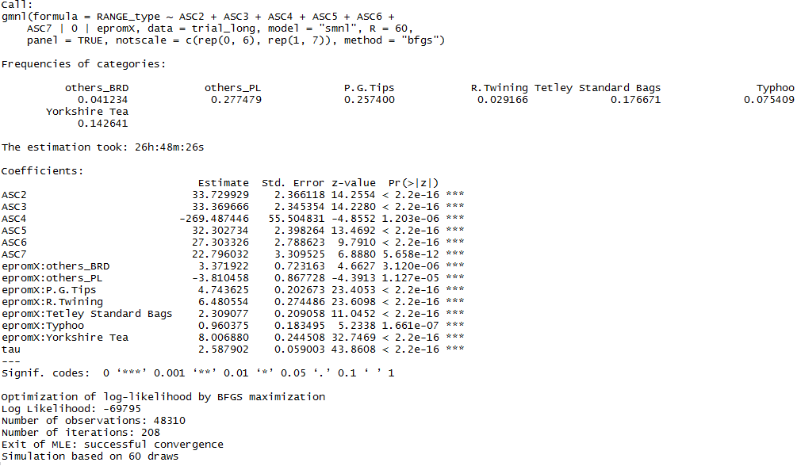

Table 4.2 The SMNL1 model with the trial data

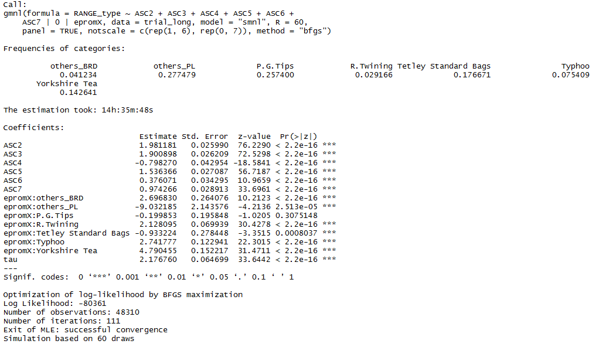

Table 4.3 The SMNL2 model with the trial data

For SMNL1, coefficients of all promotion indexes are all positive and significant except private labels, probably because it is a mixture of different private label brands and they were not often promoted as they were generally as cheap as promoted products. The confidence level of $\tau$ was found to be statistically significant as well. However, the BIC level of the model is not as good as the MIXL model, indicating that the MIXL model is better at explaining heterogeneity of the ASCs.

For the SMNL2 model, a strange result was obtained with negative coefficients for the promotion index. There are a lot of different possible reasons for not obtaining a well-fitted model.

First, the scaling factor is not alternative specific and it is shared by all the alternative attributes. As a result, it is implicitly assuming that all the alternatives and their respective attributes share the same heterogeneity structure. However, it may not be true as different attention may be spent on different attributes by different individuals on different products based on the package and display. For example, a certain brand could have their products highlighted as fair-trade products while some other brands could have their products highlighted as environmentally friendly. It is intuitive that a highlighted attributes could arouse more attention and therefore less likely to have a random error across different individuals. In our model, there is only a promotion index as the alternative attribute. However, as different brands had different promotion frequencies and strategies, it is reasonable to believe such assumption may be biased. For example, the promotion index of a brand with highlighted promotion package could have a promotion effect less random than another brand with no promotion highlight.

Second, the heterogeneity of individual preferences was not expressed by the model. In our case, different households could be loyal to different brands and therefore there could exist a fundamental difference in the ASCs across different alternatives. However, the model was not built to express such heterogeneity.

### 4.5.2 Discussion -SMNL

Recently, researchers such as Louvirere et al. (1999, 2002, 2008b) argued that MIXL cannot model the major individual heterogeneity. They argued that the major difference between individuals were their randomness in making choices. So , they suggested that a Scaled Multi-logit Model(SMNL) which was found often performing better in most of the datasets tested. This argument was further confirmed by Fiebig et al(2010) in terms of BIC, CAIC and AIC. BIC and CAIC measures were found to be better at detecting the present of scale heterogeneity. He also further suggested the reason why SMNL often performs better was due to a different degree of randomness of choices made by different individuals and their heterogeneity on the number of attributes considered by them. However, the results of the tested SMNL models were not as good as the MIXL model.

The scaling factor $\sigma_i$ can be re-modeled with demographical data as,

$$\sigma_n=exp(\bar{\sigma}+\delta D_n +\tau \nu_n)$$
,

where $\delta$ is the fitted parameters to describe the effect of demographical factors $D_n$.

# 5 Conclusion

From the testing result of the three different choice model, the MIXL model gave a much lower BIC than that of the SMNL or the LC and therefore it is believed to be the best fitting model. However, further testing should be done on the test set to further confirm the whether its predictive power is better.

Although SMNL1 shows a reasonable result in terms of the signs of the coefficients, the BIC obtained is much bigger than the BIC of the MIXL model, indicating that the MIXL model is a better fit for the data. This result can be interpreted as the variation of tea choices among different households was due to preference differences more than the difference in the randomness of choice.

# 6 Possible Further Investigation and Modelling

The data has still a lot of possibilities to explore with the models above. For instance, more attributes of products could be introduced into the model to model how the effect of different attributes of products affect the choice. Furthermore, more individual attributes such as demographical data or the consumption rate of tea could be used to explain the heterogeneity. Furthermore, many different kinds of models can be applied to further explain the variations with the dataset.

## 6.1 Further Nested and Mixed Models

In this section, we will further discuss other possible models to be applied for on the data. These models are further mixtures or nested models of the LC, MIXL or SMNL. Due to their complexity and high computing cost, they are not tested in this report. However, how the model should be built based on these models will be discussed.

### 6.1.1 Generalised Multinomial Logit Model (GMNL) - Mixed MIXL and SMNL Model

The generalized Multinomial Logit Model is a generalization of SMNL and MMNL. It combines the features of both models to describe the heterogeneity of parameters. The effects of both models are smoothed by a new parameter $\gamma$. In this model the parameter $\beta_n$ is modeled as,

$$\beta_n=\sigma_n \beta + [\gamma + \sigma_n(1-\gamma)]L \eta_n$$

where $\sigma_n$ and $\eta_n$ are modeled as in SMNL and MMNL respectively.

As gamma has a forced domain $\gamma \in [0,1]$, it is parameter by $\gamma^*$ as $\gamma = \frac{exp(\gamma^{*})}{1+exp(\gamma^{*})}$.

#### 6.1.1.1 Model Application

In this model, we should apply what we learnt from the result of SMNL and MIXL and propose a better form of models.

As we found that MIXL was a good fit for the data with the ASCs randomized, the ASCs here should also be modeled with distributions as in MIXL to model the taste preference on choosing different brands. On the other hand, from what we learnt from the SMNL1, the alternative heterogeneity of promotion should be taken care of. As the private labels were naturally under promotion price level without actual promotion, the promotion index of the private label should be removed. Only the promotion index of the top 5 major brands and other branded products were included and scaled to model the heterogeneity of importance of promotion to different households.

#### 6.1.1.2 Discussion - GMNL

A lot of researches was done (e.g. Louvirere et al. (2008b)) to compare the performance between MIXL and SMNL, it is important to note that these researches were not trying to find out an absolutely better model but to suggest another kind of heterogeneity which could be better modeled by SMNL. The two models can be applied to model different kind of individual heterogeneity at the same time and they are not contradictive. In fact, the generalization of both models, the hybrid GMNL model did perform better than SMNL or MIXL in some cases studied by Fiebig et al. 2010.

### 6.1.2 Mixture of Mixed Multinomial Logit Model(MM-MNL)

The MM-MNL is the mixture of MMNL and LC, nesting MMNL models with different parameters in different classes.

Under this model, the utility of each individual $n$ in class $c$ is then evaluated as,

$$U_{cjt}=(\beta_c+ L_c \eta_{nc}) x_{njt} + \epsilon_{njt}$$
.

#### 6.1.2.1 Model Application

As the MIXL model the variation of ASCs well, the setting should be the same as MIXL. However, as discussed in the GMNL section, the promotion index of private label will be removed. The different number of classes should be tested to find the best fit.

#### 6.1.2.2 Discussion - MM-MNL

As it is nesting MIXL within LC, it can explain more unobserved individual heterogeneity then MIXL or LC alone. The nested MIXL is expected to pick up the unexplained heterogeneity from the LC model. At the same times, the LC structure allows more different kind of distribution of coefficients to be modeled. However, it cannot model the different scale of randomness of choice modeled by SMNL or GMNL.

# 7 Appendix

## 7.1 Tested LC model with demographical factors

Some effort was put to apply a model with demographical details but no interesting pattern observed. However, other demographical factors could be useful in explaining class membership.

The BIC of the model increased slightly to 137942 and the result was presented below:

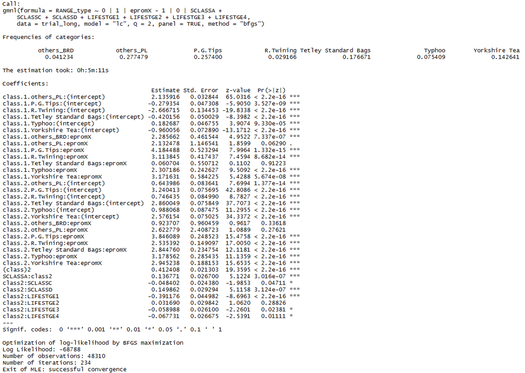

Table 2.3 The LC models with demographical factors

SCLASSA: Original SCLASS 1

SCLASSC: Original SCLASS 2 & 4

SCLASSD: Original SCLASS 5 & 6

LIFESTG1: Original LIFESTG 1

The results show what kind of demographical factors are more likely have a class membership in class 2. The result is not particularly interesting and there is no any observable pattern within.

# 8 References

Mauricio Sarrias and Ricardo A.Daziano(2005), “Multinomial Logit Models with Continuous and Discrete Individual Heterogeneity in R : The gmnl Package”, R-CRAN Studio 06 (November)

Kamakura, Wagner A. and Gary J. Russell (1989), “A Probabilistic Choice Model for Market Segmentation and Elasticity Structure,” Journal of Marketing Research, 26 (November), 379-390 [Lead Article].

DANIEL MCFADDEN AND KENNETH TRAIN (2000), “MIXED MNL MODELS FOR DISCRETE RESPONSE”, J. Appl. Econ. 15: 447-470 (2000)

Denzil G. Fiebig, Michael P. Keane, Jordan Louviere, Nada Wasi, (2010) The Generalized Multinomial Logit Model: Accounting for Scale and Coefficient Heterogeneity. Marketing Science 29(3):393-421

Louviere, J. J., D. Street, L. Burgess, N. Wasi, T. Islam, A. A. J.Marley. 2008b. Modelling the choices of individuals decision makers by combining efficient choice experiment designs with extra preference information. J. Choice Model. 1(1) 128-163.